# Kawasaki Disease: data exploration

# Inclusion criteria

The *patients* inclusion criteria is **patients < 18 at the date of visit** The *Visits* inclusion criteria includes: - Inpatients (at least one hospitalization > 1 day) - Comprising at least one ICD-10 code during hospitalization - Start date: January 1st, 2019 - End date: March 31st, 2023

# Variables that need to be checked/modified by each site

Change the values of the following variables according to your site: 1. “folder_4ce_files”: folder path where your phase 2.2 data files are located 2. “obfuscation”: determine the obfuscation threshold (FALSE if no obfuscation, or the numeric value of the obfuscation threshold if any) 3. “dateFormat”: specify the format of the date at your site (e.g., for “2021-06-24”, the format would be "“%Y-%m-%d”“, [see documentation](https://www.stat.berkeley.edu/~s133/dates.html)) 4.”data_update_date": date at which the data has been updated in the local datawarehouse. Used to estimate patient age at time of visit, since patients age in the 4CE demographic file is expected the age at data update.

```r
folder_4ce_files <- "/4ceData/Input/4CEAllAdminChortsOct2023/"
obfuscation =  FALSE
#obfuscation = 3
dateFormat <- "%Y-%m-%d"
data_update_date <- "2023-10-01"
age_estimation_variability <- FALSE
```

# Set up

- Installing and loading the libraries
- Get the session info

```r
# Install packages
source("../R/packagesInstallation.R")
# get the session information
sessionInfo()
# load the local variables
source("../R/setUpVariableParameters.R")

print(paste0( 'FourCePhase2.2kawasai_ad Code version: ', codeVersion ))
print('##########')
```

[output not shown]

# Data loading

We will use as input the 2.2 data files. Specifically: - LocalPatientSummary - LocalPatientObservation - LocalPatientClinicalcourse

## Reading 4CE phase 2.2 files

```r
### Read the CSV input files without duplicating the data

source("../R/readInputFiles_fread.R")

filecheck <- checkInputFilesFread( path = folder_4ce_files, separator = ",", skip = 0, verbose = TRUE )
```

```
## [1] "Checking if the files are located in the directory provided"
## All of  LocalPatientSummary.csv LocalPatientObservations.csv LocalPatientClinicalCourse.csv  are in the directory, input file check passed
```

```r
if(filecheck){
  demo_raw <-  data.table::fread(paste0( folder_4ce_files, "LocalPatientSummary.csv"), sep = ',',skip = 0, fill=TRUE )
  obs_raw <-  data.table::fread(paste0( folder_4ce_files, "LocalPatientObservations.csv"), sep = ',',skip = 0, fill=TRUE)
  clinical_raw <-  data.table::fread(paste0( folder_4ce_files, "LocalPatientClinicalCourse.csv"), sep = ',',skip = 0, fill=TRUE)

  ### Extract the patient summary and observation information.
  # arrange in a consistent way to make sure we are not assuming the order of some sites
  # select only the study period
  demo_raw <- demo_raw %>%
    dplyr::mutate( age = trunc( age ) ) %>%
    dplyr::filter(cohort == "AllAdm",
                  age >= 0,
                  as.Date(admission_date, format = dateFormat) >= ymd('2019-01-01'),
                  as.Date(admission_date, format = dateFormat) <= ymd('2023-03-31')) %>%
    dplyr::arrange(patient_num, as.Date(admission_date, format = dateFormat), days_since_admission)
  obs_raw <- obs_raw %>%
    dplyr::filter(cohort == "AllAdm") %>%
    dplyr::arrange(patient_num, days_since_admission)
  clinical_raw <- clinical_raw %>%
    dplyr::filter(cohort == "AllAdm",
                  as.Date(calendar_date, format = dateFormat) >= ymd('2019-01-01'),
                  as.Date(calendar_date, format = dateFormat) <= ymd('2023-03-31')) %>%
    dplyr::arrange(patient_num, as.Date(calendar_date, format = dateFormat), days_since_admission)

  print('Input files successfully read, patient data extracted')

}else{
  print('Error in reading files')
}
```

```
## [1] "Input files successfully read, patient data extracted"
```

```r
#remove potential duplicates
clinical_raw <- clinical_raw %>% unique()
demo_raw <- demo_raw %>% unique()
obs_raw <- obs_raw %>% unique()
```

## Select the ICD codes of interest

```r
print('Reading ICD code')
```

```
## [1] "Reading ICD code"
```

```r
icdCodes <- read.csv("../public-data/ICD_kawasaki.csv", header = TRUE, colClasses = "character")
```

# Data-management

## Filtering on “inpatient” status

```r
# Filtering on inpatients here (in_hospital == 1), to reduce subsequent compute time of the encounter length calculation
clinical_raw <- dplyr::filter(clinical_raw, in_hospital == 1)
```

## Calculating age at hospitalization time

```r
# Calculating patient age at the time of visit, assuming the age used is the patients' age at the time of extraction (last discharge date available in the data)
# removing the dots from the ICD codes (if any)
obs_raw <- as.data.frame( obs_raw )
demo_raw <- as.data.frame( demo_raw )
clinical_raw <- as.data.frame( clinical_raw )

obs_raw_age <- left_join(obs_raw, demo_raw[c("patient_num", "age", "dead", "death_date")], by = c("patient_num")) %>%
  dplyr::mutate( concept_code = gsub("\\.", "",concept_code )) %>%
  dplyr::inner_join(clinical_raw[, c("patient_num", "days_since_admission", "calendar_date")],
            by = c("patient_num", "days_since_admission"))

# estimate age at each diagnosis
if( age_estimation_variability == FALSE ){

  obs_raw_age <- obs_raw_age %>%
    dplyr::mutate( age_time_diagnosis = age - floor(as.numeric(as.Date(data_update_date, format = dateFormat) - as.Date(calendar_date, format = dateFormat)) / 365.25)) %>%
    dplyr::select( -dead, -death_date )

}else if( age_estimation_variability == TRUE ){

  alive<- obs_raw_age %>%
    dplyr::filter( dead == 0 ) %>%
    dplyr::mutate( age_time_diagnosis = age - floor(as.numeric(as.Date(data_update_date, format = dateFormat) - as.Date(calendar_date, format = dateFormat)) / 365.25 )) %>%
    dplyr::select( -dead, -death_date )

  dead<- obs_raw_age %>%
    dplyr::filter( dead == 1 ) %>%
    dplyr::mutate( age_time_diagnosis = age - floor(as.numeric(as.Date(death_date, format = dateFormat) - as.Date(calendar_date, format = dateFormat)) / 365.25 )) %>%
    dplyr::select( -dead, -death_date )
 obs_raw_age <- rbind( alive, dead )
}

print('Patient age calculated')
```

```
## [1] "Patient age calculated"
```

## Applying inclusion criteria to filter and format the data

We are selecting hospitalizations based on the following criteria:

- Associated with at least 1 ICD code
- With a duration of hospitalization spanning over at least one consecutive days
- Starting on or after 2019/01/01
- Age at diagnosis < 18 y/o

```r
obs_filtered_inclusion_criteria <- obs_raw_age %>%
  dplyr::filter(concept_type == 'DIAG-ICD10',
                days_since_admission >= 0,
                age_time_diagnosis < 18 )
```

## Select the disorders of interest based on the ICD code

```r
obs_disease_interest <- obs_filtered_inclusion_criteria %>%
  dplyr::filter( concept_code %in% icdCodes$ICD10_Code )
```

## Estimate the length of the hospitalization

```r
source("../R/count_sequences_hospitalisation.R")

clinical_raw_doi <- clinical_raw %>%
  dplyr::filter( patient_num %in% obs_disease_interest$patient_num )

clinical_raw_doi <- count_hosp(clinical_raw_doi) %>%
  dplyr::ungroup() %>%
  dplyr::select( patient_num, days_since_admission, n_hospitalization, length_hospitalization, admit_date )
```

## Hospitalizations per month to plot

```r
toPlot_formated <- obs_disease_interest %>%
  dplyr::left_join( clinical_raw_doi, by=c("patient_num", "days_since_admission")) %>%
  dplyr::mutate( time_p = as.Date(cut( as.Date(admit_date), breaks = "months"))) %>%
  dplyr::filter( as.Date(time_p) >= ymd(start_date_plots),
                 as.Date(time_p) <= ymd(end_date_plots))

toPlot_counts <- toPlot_formated %>%
  dplyr::mutate( pat_hosp = paste0( patient_num, "-", n_hospitalization )) %>%
  dplyr::group_by( time_p ) %>%
  #dplyr::summarise( n = n_distinct( pat_hosp )) %>%
  dplyr::summarise( n = ifelse(n_distinct(pat_hosp) > obfuscation | isFALSE(obfuscation),
                               n_distinct(pat_hosp),
                               0.5))
```

## Plot cases per month

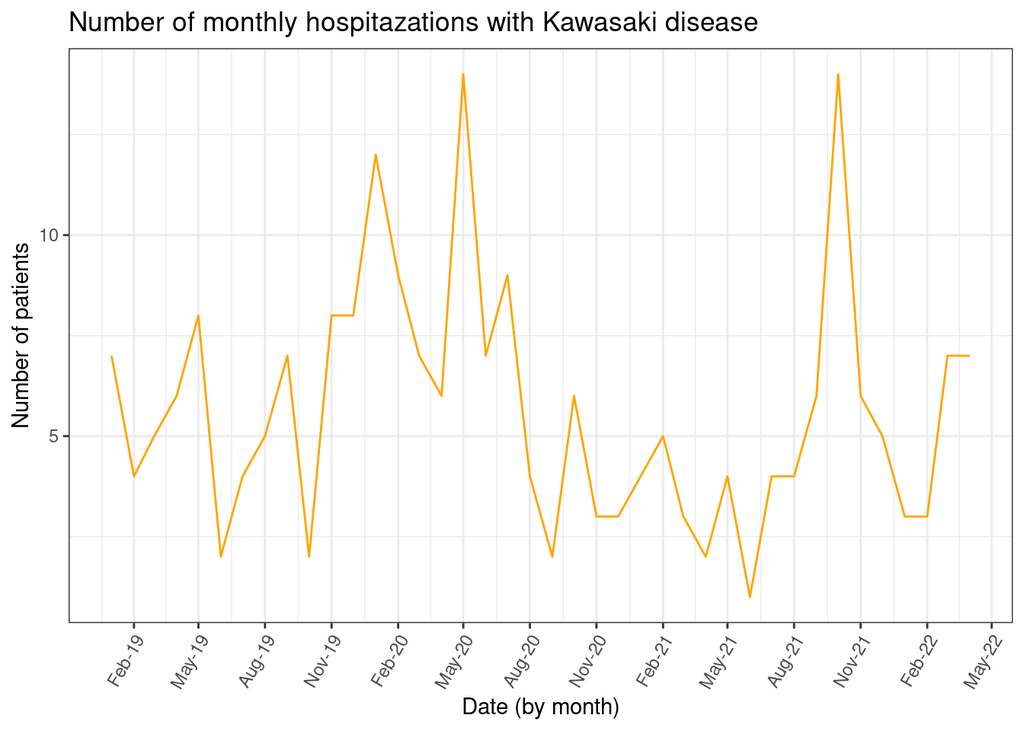

```r
ggplot2::ggplot(data=toPlot_counts, aes(x=time_p, y=n)) +
  ggplot2::geom_line( color = "orange") +
  ggplot2::scale_x_date(date_labels="%b-%y",date_breaks  ="3 month")+
  ggplot2::labs(y = "Number of patients",
                x = "Date (by month)",
                title = "Number of monthly hospitazations with Kawasaki disease") +
  ggplot2::theme_bw() +
  ggplot2::theme(axis.text.x = element_text(angle = 60, hjust = 1))
```

## Create table 1

```r
demog_table <- toPlot_formated %>%
  dplyr::left_join( demo_raw %>% dplyr::select( patient_num, sex ), by = "patient_num" ) %>%
  dplyr::select( patient_num, sex, age_time_diagnosis, length_hospitalization,n_hospitalization ) %>%
  unique()
```

```r
age <- demog_table %>%
  dplyr::mutate( age_time_diagnosis = ifelse( age_time_diagnosis == -1, 0, age_time_diagnosis )) %>%
  dplyr::mutate( pat_hosp = paste0( patient_num, "-", n_hospitalization )) %>%
  dplyr::summarise( mean = mean( age_time_diagnosis ),
                    sd = sd( age_time_diagnosis ),
                    count = n_distinct(pat_hosp)) %>%
  dplyr::mutate( count = ifelse( count > obfuscation, count, obfuscation * 0.5))
```

```r
sex <- demog_table %>%
  dplyr::mutate( hospitalization_id = paste0( patient_num, "-", n_hospitalization )) %>%
  dplyr::distinct(hospitalization_id, sex) %>%
  dplyr::group_by( sex ) %>%
  dplyr::summarise( count = n_distinct(hospitalization_id) ) %>%
  dplyr::mutate( count = ifelse( count > obfuscation, count, obfuscation * 0.5),
                 total = sum( count ), percentage = round( count/total*100, 2)  )
```

```r
hosp_length <- demog_table %>%
  dplyr::mutate( pat_hosp = paste0( patient_num, "-", n_hospitalization )) %>%
  dplyr::summarise( mean = mean( length_hospitalization ),
                    sd = sd( length_hospitalization ),
                    count = n_distinct(pat_hosp)) %>%
  dplyr::mutate( count = ifelse( count > obfuscation, count, obfuscation * 0.5))
```

```r
format_counts <- function(count, percentage) {
  glue::glue("{count} ({percentage} %)", count = count, percentage = percentage)
}

age_table1 <- age %>%
  mutate(result = glue::glue("{mean} (sd: {sd})", mean = round(mean, 2), sd = round(sd, 2))) %>%
  select(result) %>%
  mutate(name = "Age")

sex_table1 <- sex %>%
  mutate(result = format_counts(count, percentage)) %>%
  select(-c(count, percentage)) %>%
  rename(name = sex)

hosp_length_table1 <- hosp_length %>%
  mutate(result = glue::glue("{mean} (sd: {sd})", mean = round(mean, 2), sd = round(sd, 2))) %>%
  select(result) %>%
  mutate(name = "Length of Hospitalization")

list_table1 <- list(
  "Sex" = sex_table1,
  "Age" = age_table1,
  "Length of Hospitalization" = hosp_length_table1)


table1 <- list_table1 %>%
  lapply(function(df) mutate(df, across(.fns = as.character)))

table1
```

```
## $Sex
## # A tibble: 2 x 3
##   name   total result
##   <chr>  <chr> <chr>
## 1 female 226   84 (37.17 %)
## 2 male   226   142 (62.83 %)
##
## $Age
##           result name
## 1 4.1 (sd: 3.49)  Age
##
## $`Length of Hospitalization`
##             result                      name
## 1 6.72 (sd: 17.49) Length of Hospitalization
```

```r
table1(~ sex + age_time_diagnosis +  length_hospitalization,
       data = demog_table, caption = "Table 1. Kawasaki Disease Hospitalizations")
```

[output not shown]